# Probing nonlinear interactions with interprobe()

Uri Simonsohn

2026-10-30

# Why probe without assuming linearity?

Classical interaction models of the form `y ~ x * z` assume that the effect of `x` on `y` changes *linearly* with `z` (the linear interaction effect, or LIE, assumption). That assumption is often false, and when it is false, both the test of the interaction and the Johnson-Neyman / spotlight probes can mislead.

`interprobe()` estimates a flexible GAM by default, then draws:

- **Simple slopes** (spotlights): predicted `y` at selected values of one predictor across the range of the other
- **Johnson-Neyman** curves: the marginal effect of the focal predictor across the moderator

**Estimand.** For categorical `x` (2-3 levels), the quantity of interest is the difference in predicted `y` between levels of `x` as a function of `z`. For continuous `x`, it is the derivative $\partial y / \partial x$ at given values of `z` (or the reverse, depending on which variable is on the x-axis).

## A simulated case where the linear interaction is wrong

The bundled dataset `interprobe_sim` has a binary treatment whose true effect rises with the moderator and then flattens: $2(1 - e^{-\mathrm{mod}/3})$.

```r
data(interprobe_sim)
# True effect at a few moderator values
mod_grid <- c(1, 3, 5, 9)
true_eff <- 2 * (1 - exp(-mod_grid / 3))
cbind(mod = mod_grid, true_effect = round(true_eff, 2))
```

```
#>      mod true_effect
#> [1,]   1        0.57
#> [2,]   3        1.26
#> [3,]   5        1.62
#> [4,]   9        1.90
```

```r
interprobe(
  x = treat, z = mod, y = y,
  data = interprobe_sim,
  quiet = TRUE
)
```

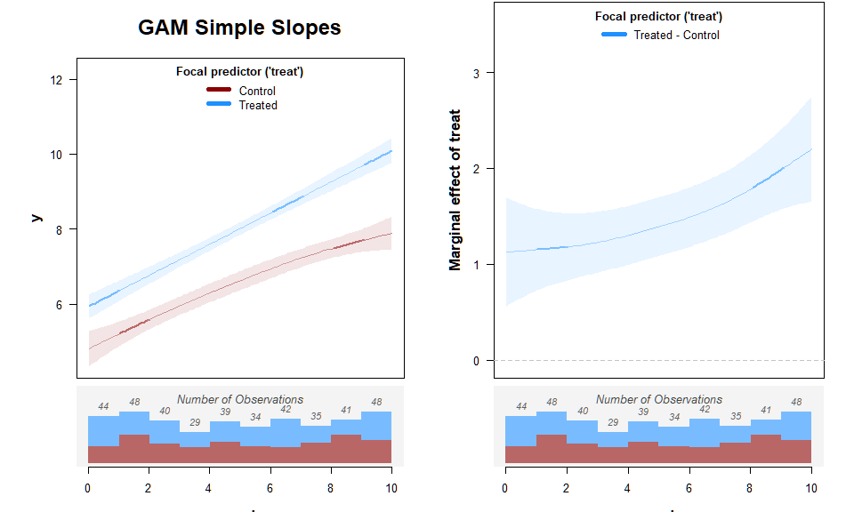

Compare with a linear probe of the same data: the linear model forces a straight Johnson-Neyman line even though the true effect curves.

```r
interprobe(
  x = treat, z = mod, y = y,
  data = interprobe_sim,
  model = "linear",
  quiet = TRUE
)
```

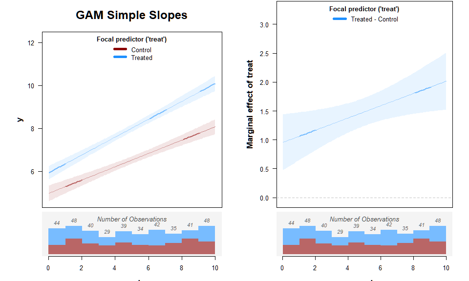

For every argument, defaults, and return-value columns, see `?interprobe`. Run `citation("statuser")` for the papers behind this method.

# Data setup (MASS::birthwt)

The remaining examples use the `birthwt` data from **MASS**, with smoking and race coded as labeled factors.

```r
bw <- MASS::birthwt
bw$smoke <- factor(bw$smoke, levels = c(0, 1), labels = c("No", "Yes"))
bw$race <- factor(bw$race, levels = c(1, 2, 3),
                  labels = c("White", "Black", "Other"))
```

# Case A: binary x × continuous moderator

Smoking (`smoke`) by mother’s age (`age`), predicting birth weight (`bwt`).

```r
res_a <- interprobe(x = smoke, z = age, y = bwt, data = bw)
```

```
#> Probing the interaction of 'smoke' * 'age'
#> p-value for the interaction:
#>   linear model: t(185) = -2.07, p = 0.040 (robust errors: HC3)
#>   GAM: F(1.00, 1.00) = 4.05, p = 0.045
```

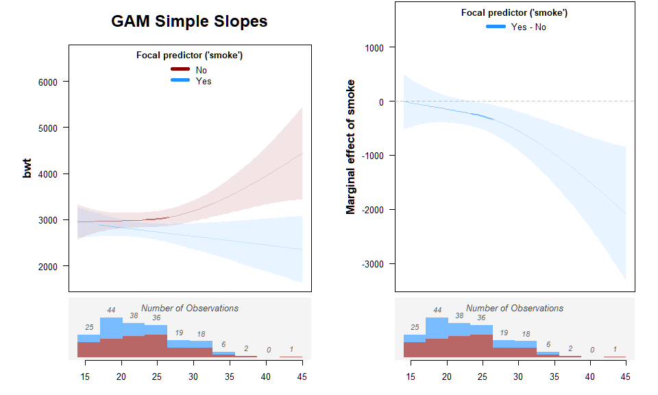

```
#> Johnson-Neyman Regions of Significance
#> 1) The contrast for 'smoke' of Yes - No is negative in the range of 'age': [23.39 to 45]
#>
#>
#> Notes:
#> 1) Regions of significance reported by interprobe() never include values outside
#> range of observed data.
#> 2) These regions are precise to 1/100 of the range of x-values. For
#> greater precision (and slower estimation) set 'probe.bins' to a value greater than '100'.
```

**How to read the figure.**

- The **left panel** (simple slopes) shows predicted birth weight as a function of age, separately for smokers and nonsmokers. Darker / thicker lines mark regions with more data (`n.max` controls when darkness saturates).
- The **right panel** (Johnson-Neyman) shows the smoking effect (smoker minus nonsmoker) across age, with a confidence band. Where the band excludes zero, the effect is significant.
- The **histogram** under each panel shows the distribution of the moderator (common support).

Unless `quiet = TRUE`, the console also prints an HC3 linear interaction test and a GAM interaction F test for the internal GAM fit.

# Case B: 3-level categorical x

Race (`race`) by age.

```r
res_b <- interprobe(x = race, z = age, y = bwt, data = bw)
```

```
#> Probing the interaction of 'race' * 'age'
#> p-value for the interaction:
#>   linear model: unavailable
#>   GAM: F(2.33, 2.97) = 2.16, p = 0.083
```

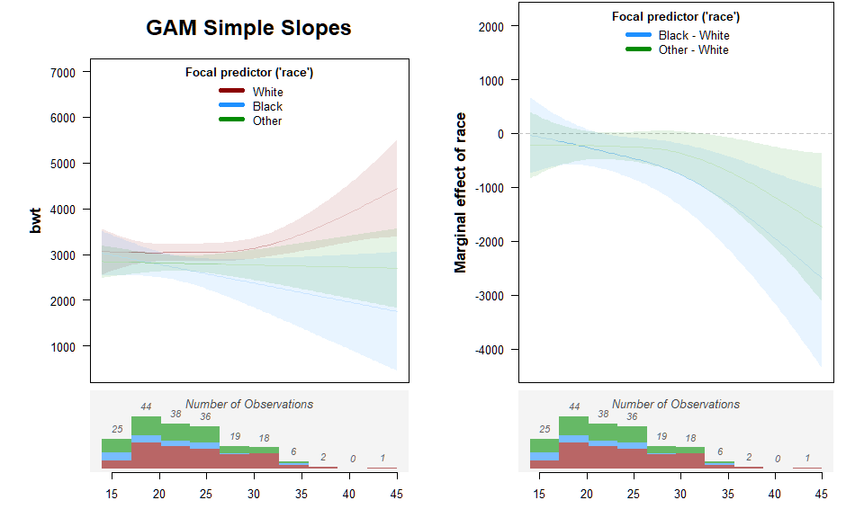

```
#> Johnson-Neyman Regions of Significance
#> 1) The contrast for 'race' of Black - White is negative in the range of 'age': [21.83 to 45]
#> 2) The contrast for 'race' of Other - White is negative in the range of 'age': [32.16 to 45]
#>
#>
#> Notes:
#> 1) Regions of significance reported by interprobe() never include values outside
#> range of observed data.
#> 2) These regions are precise to 1/100 of the range of x-values. For
#> greater precision (and slower estimation) set 'probe.bins' to a value greater than '100'.
```

With 2-3 unique values of `x`, `interprobe()` treats the focal predictor as **categorical**: one curve per level, spotlights unused, and Johnson-Neyman regions of significance printed to the console (pairwise contrasts across the moderator).

# Case C: continuous × continuous

Mother’s age (`age`) by mother’s weight (`lwt`).

```r
res_c <- interprobe(x = age, z = lwt, y = bwt, data = bw)
```

```
#> Probing the interaction of 'age' * 'lwt'
#> p-value for the interaction:
#>   linear model: t(185) = -0.87, p = 0.387 (robust errors: HC3)
#>   GAM: F(1.00, 1.00) = 1.08, p = 0.299
```

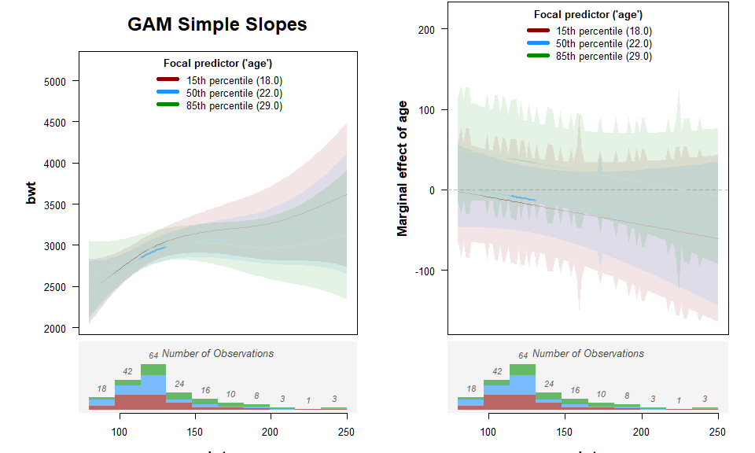

For continuous (or discrete with more than 3 values) predictors, three **spotlights** are used. The default is the 15th, 50th, and 85th percentiles of the off-axis variable. You can set your own:

```r
interprobe(
  x = age, z = lwt, y = bwt, data = bw,
  spotlights = c(110, 130, 160),
  spotlight.labels = c("Light (110)", "Typical (130)", "Heavy (160)"),
  quiet = TRUE
)
```

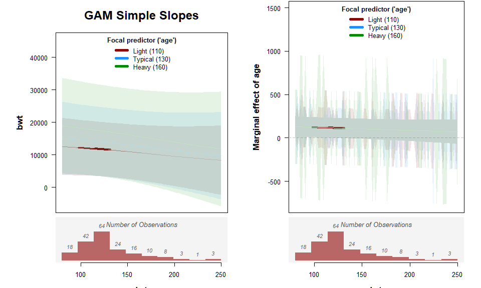

By default the moderator is on the x-axis (`moderator.on.x.axis = TRUE`). Set it to `FALSE` to put the focal predictor on the x-axis (ignored when `x` has 3 or fewer unique values).

```r
interprobe(
  x = age, z = lwt, y = bwt, data = bw,
  moderator.on.x.axis = FALSE,
  quiet = TRUE
)
```

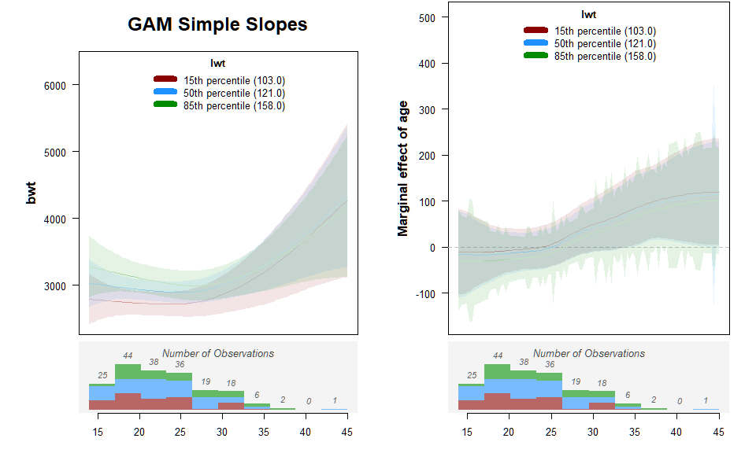

# Covariates

To include covariates, fit the model yourself and pass it as `model`. Other predictors are held at their means on the prediction grid.

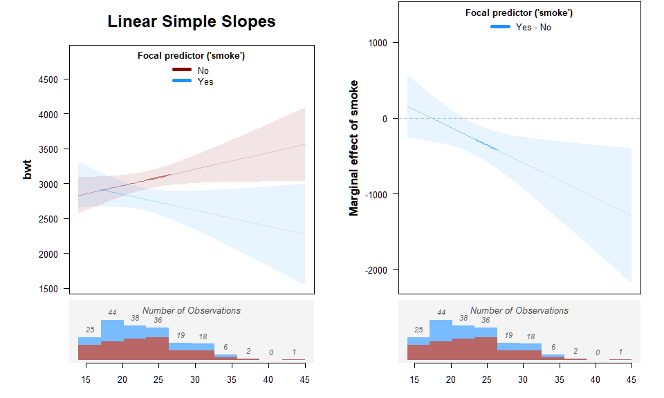

```r
fit <- lm(bwt ~ smoke * age + lwt, data = bw)
interprobe(model = fit, x = smoke, z = age, quiet = TRUE)
```

You can also pass `lm2()`, `glm()`, or `mgcv::gam()` fits.

# GAM vs model = “linear”

Same data, two engines:

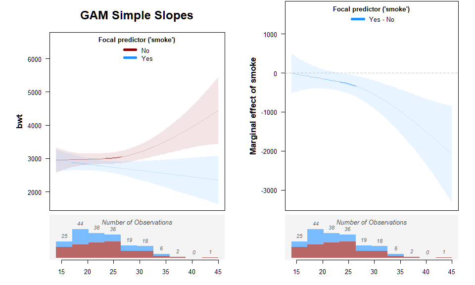

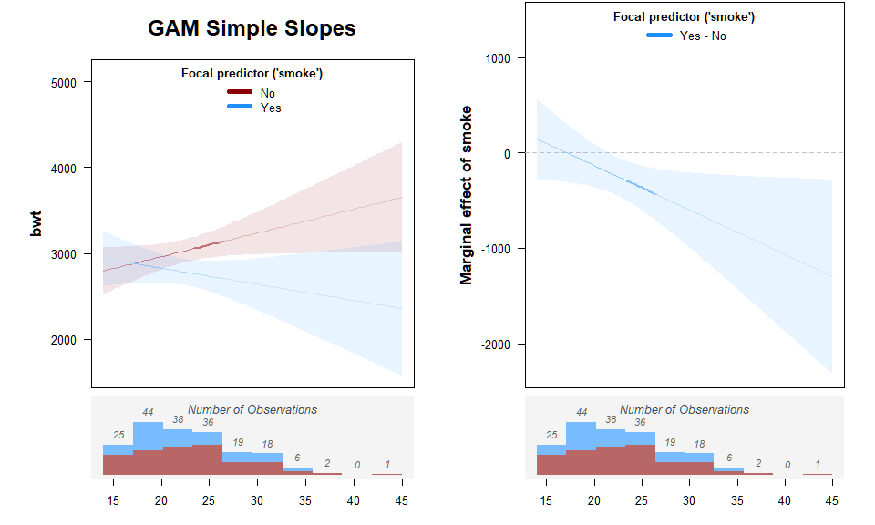

```r
interprobe(x = smoke, z = age, y = bwt, data = bw, quiet = TRUE)
interprobe(x = smoke, z = age, y = bwt, data = bw, model = "linear", quiet = TRUE)
```

Use the GAM default when you want robustness to nonlinearities. Use `model = "linear"` when you specifically want the classical linear interaction probed (or when a GAM will not converge; see Troubleshooting).

# Working with the returned list

`interprobe()` returns (invisibly) a list. Capture it to reuse the numeric results without redrawing.

```r
res <- interprobe(
  x = smoke, z = age, y = bwt, data = bw,
  draw = "none", quiet = TRUE
)
names(res)
```

```
#> [1] "simple.slopes"       "johnson.neyman"      "frequencies"
#> [4] "gam_results"         "gam_results_testing" "lm2_results"
```

```r
head(res$johnson.neyman)
```

```
#>     contrast      age marginal.effect std.error   p.value  conf.low conf.high
#> 101 Yes - No 14.00000       -11.07116  258.1041 0.9657859 -516.9458  494.8035
#> 102 Yes - No 14.31313       -18.16952  246.9466 0.9413472 -502.1759  465.8368
#> 103 Yes - No 14.62626       -25.26110  236.2366 0.9148434 -488.2763  437.7541
#> 104 Yes - No 14.93939       -32.33913  226.0245 0.8862286 -475.3390  410.6607
#> 105 Yes - No 15.25253       -39.39752  216.3368 0.8554949 -463.4099  384.6149
#> 106 Yes - No 15.56566       -46.43522  207.1846 0.8226602 -452.5096  359.6392
#>     smoke
#> 101   Yes
#> 102   Yes
#> 103   Yes
#> 104   Yes
#> 105   Yes
#> 106   Yes
```

```r
head(res$simple.slopes)
```

```
#>        age    y.hat std.error conf.low conf.high  df
#> 1 14.00000 2951.602  196.7027 2566.072  3337.132 Inf
#> 2 14.31313 2952.797  185.8041 2588.628  3316.967 Inf
#> 3 14.62626 2953.986  175.3904 2610.227  3297.745 Inf
#> 4 14.93939 2955.161  165.5356 2630.717  3279.604 Inf
#> 5 15.25253 2956.316  156.2853 2650.002  3262.629 Inf
#> 6 15.56566 2957.451  147.6632 2668.036  3246.865 Inf
```

When a model is estimated inside `interprobe()`, `res$gam_results` holds that fit (an `lm2` object if you used `model = "linear"`). For a binary focal predictor under the GAM engine, `res$gam_results_testing` and `res$lm2_results` support the printed interaction tests.

```r
summary(res$gam_results)
```

```
#>
#> Family: gaussian
#> Link function: identity
#>
#> Formula:
#> bwt ~ s(age, by = smoke) + smoke
#>
#> Parametric coefficients:
#>             Estimate Std. Error t value Pr(>|t|)
#> (Intercept)  3049.56      65.57  46.508  < 2e-16 ***
#> smokeYes     -283.15     104.80  -2.702  0.00754 **
#> ---
#> Signif. codes:  0 '***' 0.001 '**' 0.01 '*' 0.05 '.' 0.1 ' ' 1
#>
#> Approximate significance of smooth terms:
#>                   edf Ref.df     F p-value
#> s(age):smokeNo  2.251  2.865 2.968  0.0296 *
#> s(age):smokeYes 1.001  1.002 1.336  0.2491
#> ---
#> Signif. codes:  0 '***' 0.001 '**' 0.01 '*' 0.05 '.' 0.1 ' ' 1
#>
#> R-sq.(adj) =  0.0729   Deviance explained = 9.39%
#> -REML =   1485  Scale est. = 4.9297e+05  n = 189
```

# Saving and customizing figures

Brief options (full list in `?interprobe`):

```r
interprobe(
  x = smoke, z = age, y = bwt, data = bw,
  draw = "jn",                    # or "simple slopes", "both", "none"
  cols = c("black", "steelblue"),
  save.as = "smoke_age_jn.png",
  xlim = c(15, 40),
  quiet = TRUE
)
```

# Troubleshooting

- **GAM estimation fails.** Predictors with few unique values often need a smaller basis: try `k = 3` or `k = 2`.
- **Only one unique value of `x` or `z`.** `interprobe()` stops; there is nothing to probe.
- **`cols` length.** Binary focal predictors need length 2 (or 3); continuous / discrete spotlights and 3-level categorical need length 3.
- **`spotlights` length.** Must be length 3 when supplied.
- **Both `data` and `model`.** Not allowed; pick one input path.

# References

Simonsohn, U. (2024). Interacting with curves: How to validly test and probe interactions in the real (nonlinear) world. *Advances in Methods and Practices in Psychological Science*, 7(1), Article 25152459231207787. https://doi.org/10.1177/25152459231207787

Montealegre, D., & Simonsohn, U. (2026). *Johnson Neyman 2.0* (working paper).

Run `citation("statuser")` for ready-to-use BibTeX / text citations.